# Pre-processing & Deriving Conditional League Strengths

## Data Overview

The following data was gathered using the `worldfootballR` library to scrape 2019-20 UEFA Champions League group stage and knockout game results and the 2018-19 domestic league results for the 32 competing teams across 16 individual league competitions[^1] from fbref.com.

## Data Pre-processing

In order to use the domestic competition and UEFA Champions League matchup data scraped from [fbref.com](https://www.fbref.com/)[^2] with the Bradley-Terry package, `BradleyTerry2`, the raw data must first be cleaned, parsed, and reformated into the package’s expected format. This code follows that found in Lecture 12 (Deshpande 2025), particularly when refactoring home and away win data into a trainable DataFrame.

```
# Helper to remove xG columns from relevant leagues so all competitions have the same number of columns
remove_xg = function(df){
  if((df %>% select(contains('_xG')) %>% length()) > 0){
    return(df %>% select(-contains('_xG')))
  }
  else {
    return(df)
  }
}
austria = remove_xg(austria)
belgium = remove_xg(belgium)
croatia = remove_xg(croatia)
czech = remove_xg(czech)
england = remove_xg(england)
france = remove_xg(france)
germany = remove_xg(germany)
greece = remove_xg(greece)
italy = remove_xg(italy)
nether = remove_xg(nether)
portugal = remove_xg(portugal)
russia = remove_xg(russia)
serbia = remove_xg(serbia)
spain = remove_xg(spain)
turkey = remove_xg(turkey)
ukraine = remove_xg(ukraine)
```

```
# Concatenate all leagues together
all = austria %>%
  rbind(belgium) %>%
  rbind(croatia) %>%
  rbind(czech) %>%
  rbind(england) %>%
  rbind(france) %>%
  rbind(germany) %>%
  rbind(greece) %>%
  rbind(italy) %>%
  rbind(nether) %>%
  rbind(portugal) %>%
  rbind(russia) %>%
  rbind(serbia) %>%
  rbind(spain) %>%
  rbind(turkey) %>%
  rbind(ukraine)
all %>% head(10)
```

| Competition_Name | Gender | Country | Season_End_Year | Round | Wk | Day | Date | Time | Home | HomeGoals | Away | AwayGoals | Attendance | Venue | Referee | Notes | MatchURL |
| --- | --- | --- | --- | --- | --- | --- | --- | --- | --- | --- | --- | --- | --- | --- | --- | --- | --- |
| Austrian Football Bundesliga | M | AUT | 2019 | Regular season | 1 | Fri | 2018-07-27 | 20:45:00 | Austria Wien | 2 | Wacker Innsbr | 1 | 12673 | Generali Arena | Christopher Jäger | NA | https://fbref.com/en/matches/6c36d5e8/Austria-Wien-Wacker-Innsbruck-July-27-2018-Austrian-Bundesliga |
| Austrian Football Bundesliga | M | AUT | 2019 | Regular season | 1 | Sat | 2018-07-28 | 17:00:00 | SCR Altach | 2 | Mattersburg | 3 | 4523 | CASHPOINT Arena | Dieter Muckenhammer | NA | https://fbref.com/en/matches/b5940ee5/Rheindorf-Altach-Mattersburg-July-28-2018-Austrian-Bundesliga |
| Austrian Football Bundesliga | M | AUT | 2019 | Regular season | 1 | Sat | 2018-07-28 | 17:00:00 | Sturm Graz | 3 | Hartberg | 2 | 10785 | Merkur Arena | Rene Eisner | NA | https://fbref.com/en/matches/f54b7835/Sturm-Graz-Hartberg-July-28-2018-Austrian-Bundesliga |
| Austrian Football Bundesliga | M | AUT | 2019 | Regular season | 1 | Sun | 2018-07-29 | 17:00:00 | St. Pölten | 4 | Wolfsberger AC | 3 | 2786 | NV Arena | Robert Schörgenhofer | NA | https://fbref.com/en/matches/44323758/St-Polten-Wolfsberger-AC-July-29-2018-Austrian-Bundesliga |
| Austrian Football Bundesliga | M | AUT | 2019 | Regular season | 1 | Sun | 2018-07-29 | 17:00:00 | Admira | 0 | Rapid Wien | 3 | 5200 | BSFZ-Arena | Alexander Harkam | NA | https://fbref.com/en/matches/9b206c50/Admira-Wacker-Modling-Rapid-Wien-July-29-2018-Austrian-Bundesliga |
| Austrian Football Bundesliga | M | AUT | 2019 | Regular season | 1 | Sun | 2018-07-29 | 17:00:00 | RB Salzburg | 3 | LASK | 1 | 11532 | Red Bull Arena | Harald Lechner | NA | https://fbref.com/en/matches/7704f43d/Red-Bull-Salzburg-LASK-July-29-2018-Austrian-Bundesliga |
| Austrian Football Bundesliga | M | AUT | 2019 | Relegation round | 1 | Sat | 2019-03-30 | 17:00:00 | Hartberg | 0 | Wacker Innsbr | 2 | 4635 | PROfertil ARENA | Stefan Ebner | NA | https://fbref.com/en/matches/ed31c559/Hartberg-Wacker-Innsbruck-March-30-2019-Austrian-Bundesliga |
| Austrian Football Bundesliga | M | AUT | 2019 | Relegation round | 1 | Sat | 2019-03-30 | 17:00:00 | SCR Altach | 2 | Mattersburg | 1 | 4048 | CASHPOINT Arena | Manuel Schüttengruber | NA | https://fbref.com/en/matches/9473e323/Rheindorf-Altach-Mattersburg-March-30-2019-Austrian-Bundesliga |
| Austrian Football Bundesliga | M | AUT | 2019 | Relegation round | 1 | Sat | 2019-03-30 | 17:00:00 | Rapid Wien | 3 | Admira | 0 | 11600 | Allianz Stadion | Rene Eisner | NA | https://fbref.com/en/matches/0cc0fe4a/Rapid-Wien-Admira-Wacker-Modling-March-30-2019-Austrian-Bundesliga |
| Austrian Football Bundesliga | M | AUT | 2019 | Championship round | 1 | Sun | 2019-03-31 | 14:30:00 | Sturm Graz | 0 | St. Pölten | 1 | 8567 | Merkur Arena | Dominik Ouschan | NA | https://fbref.com/en/matches/ea07224c/Sturm-Graz-St-Polten-March-31-2019-Austrian-Bundesliga |

With the leagues all concatenated together, we can check to see the distribution of the complete DataFrame’s members.

| Competition_Name | Gender | Country | Season_End_Year | Round | Wk | Day | Date | Time | Home | HomeGoals | Away | AwayGoals | Attendance | Venue | Referee | Notes | MatchURL |
| --- | --- | --- | --- | --- | --- | --- | --- | --- | --- | --- | --- | --- | --- | --- | --- | --- | --- |
| Süper Lig | M | TUR | 2019 | NA | 28 | Sun | 2019-04-14 | 16:00:00 | Yeni Mal'spor | 1 | Alanyaspor | 1 | NA | Yeni Malatya Stadyumu | Serkan Çınar | NA | https://fbref.com/en/matches/c132193e/Yeni-Malatyaspor-Alanyaspor-April-14-2019-Super-Lig |
| La Liga | M | ESP | 2019 | NA | 22 | Sun | 2019-02-03 | 12:00:00 | Villarreal | 2 | Espanyol | 2 | 15476 | Estadio de la Cerámica | Guillermo Cuadra | NA | https://fbref.com/en/matches/9172e3c8/Villarreal-Espanyol-February-3-2019-La-Liga |
| Ligue 1 | M | FRA | 2019 | Ligue 1 | 35 | Fri | 2019-05-03 | 20:45:00 | Strasbourg | 1 | Marseille | 1 | 25962 | Stade de la Meinau | Jérôme Miguelgorry | NA | https://fbref.com/en/matches/3149818a/Strasbourg-Marseille-May-3-2019-Ligue-1 |
| La Liga | M | ESP | 2019 | NA | 1 | Sat | 2018-08-18 | 18:15:00 | Celta Vigo | 1 | Espanyol | 1 | 16215 | Estadio de Balaídos | Santiago Jaime | NA | https://fbref.com/en/matches/a8d60ff6/Celta-Vigo-Espanyol-August-18-2018-La-Liga |
| Serbian SuperLiga | M | SRB | 2019 | Regular season | 13 | Sun | 2018-10-28 | 16:30:00 | Mačva Šabac | 0 | Red Star | 2 | 5000 | Stadion FK Mačva | Ilja Brdar | NA | https://fbref.com/en/matches/296ba160/Macva-Sabac-Red-Star-October-28-2018-Serbian-SuperLiga |
| Eredivisie | M | NED | 2019 | Eredivisie | 6 | Sat | 2018-09-22 | 18:30:00 | Fortuna Sittard | 4 | Willem II | 4 | 8537 | Fortuna Sittard Stadion | Allard Lindhout | NA | https://fbref.com/en/matches/41f2a6a6/Fortuna-Sittard-Willem-II-September-22-2018-Eredivisie |
| La Liga | M | ESP | 2019 | NA | 36 | Sat | 2019-05-04 | 13:00:00 | Levante | 4 | Rayo Vallecano | 1 | 19868 | Estadio Ciudad de Valencia | Daniel Ask | NA | https://fbref.com/en/matches/05f0ac3a/Levante-Rayo-Vallecano-May-4-2019-La-Liga |
| Primeira Liga | M | POR | 2019 | NA | 28 | Sun | 2019-04-07 | 15:00:00 | Vitória Setúbal | 1 | Marítimo | 0 | 2702 | Estádio do Bonfim | Manuel Oliveira | NA | https://fbref.com/en/matches/1f7bc799/Vitoria-Setubal-Maritimo-April-7-2019-Primeira-Liga |
| Serie A | M | ITA | 2019 | NA | 27 | Sun | 2019-03-10 | 15:00:00 | Sampdoria | 1 | Atalanta | 2 | 20896 | Stadio Comunale Luigi Ferraris | Michael Fabbri | NA | https://fbref.com/en/matches/38ee4d56/Sampdoria-Atalanta-March-10-2019-Serie-A |
| Ukrainian Premier League | M | UKR | 2019 | Regular season | 16 | Sun | 2018-11-25 | 19:30:00 | FC Oleksandriya | 2 | Dynamo Kyiv | 1 | 2478 | KSK Nika | Ihor Paskhal | NA | https://fbref.com/en/matches/bbe5bffb/FC-Oleksandriya-Dynamo-Kyiv-November-25-2018-Ukrainian-Premier-League |

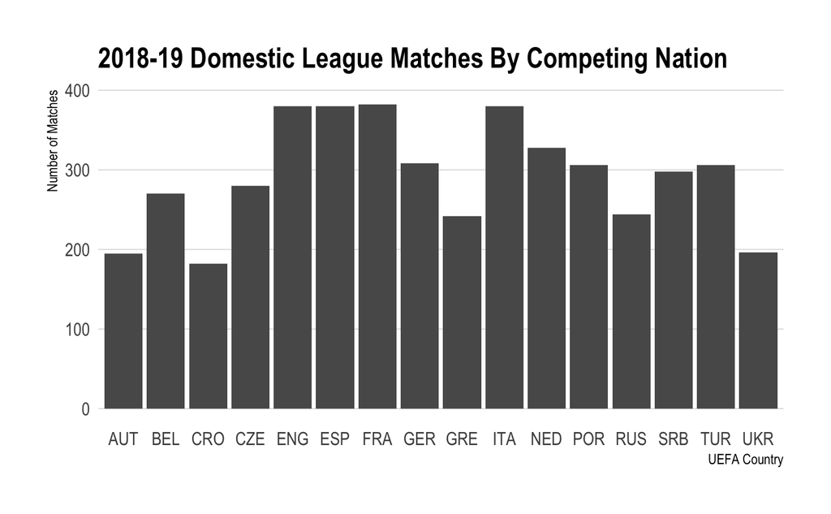

```
# CODE FROM LECTURE 12
# results <-
#  no_ties |>
#  dplyr::rename(home.team = Home, away.team = Opponent) |>
#  dplyr::group_by(home.team, away.team) |>
#  dplyr::summarise(
#    home.win = sum(Home_Winner),
#    away.win = sum(Opp_Winner), .groups = 'drop') |>
#  dplyr::mutate(
#    home.team = factor(home.team, levels = unik_teams),
#    away.team = factor(away.team,levels = unik_teams))
no_ties = all %>% filter(HomeGoals != AwayGoals) %>%
  filter(!str_detect(Round, "play-offs") | is.na(Round)) %>% ## removing matchups in pro/rel playoffs, otherwise we'll see skewed strengths for those leagues
  mutate(Home_Winner = case_when(HomeGoals > AwayGoals ~ 1, .default=0),
         Opp_Winner = case_when(AwayGoals > HomeGoals ~ 1, .default=0))

unik_teams = sort(unique(c(no_ties$Home, no_ties$Away)))

results = no_ties %>%
  rename(home.team = Home, away.team = Away) %>%
  group_by(home.team, away.team) %>%
  dplyr::summarise(
    home.win = sum(Home_Winner),
    away.win = sum(Opp_Winner), .groups = 'drop') |>
  dplyr::mutate(
    home.team = factor(home.team, levels = unik_teams),
    away.team = factor(away.team, levels = unik_teams))
results[sample(1:nrow(results),size=10),]
```

| home.team | away.team | home.win | away.win |
| --- | --- | --- | --- |
| Leverkusen | Bayern Munich | 1 | 0 |
| PSV Eindhoven | Vitesse | 1 | 0 |
| Real Sociedad | Villarreal | 0 | 1 |
| Partizan | Mladost Lučani | 1 | 0 |
| Nice | Dijon | 0 | 1 |
| Austria Wien | RB Salzburg | 0 | 2 |
| Benfica | Feirense | 1 | 0 |
| Real Madrid | Valladolid | 1 | 0 |
| Girona | Betis | 0 | 1 |
| Ural | Anzhi | 0 | 1 |

With the data now in place and formatted for `BradleyTerry2`, we can begin fitting a Bradley-Terry model to determine latent team strength for all clubs competing in the 2019-20 UEFA Champions League group stage based on their domestic league results.

## Fitting Bradley-Terry Model Based on Domestic League Results

For this problem, we’ll use the worst performing team in the lowest-rated domestic competition based on the UEFA association club coefficient[^3] for the 2018-19 season, which can be found at [UEFA.com](https://www.uefa.com/nationalassociations/uefarankings/country/?year=2019).

#### Table: 2018-19 UEFA association club coefficients for competing nations

```
country_coefficients = read_csv('../data/raw/League_Participant_Info_2018-19.csv') %>%
  select(full_name, last_association_coef) %>%
  rename(Country = full_name, Coefficient = last_association_coef) %>%
  arrange(desc(Coefficient))

country_coefficients
```

| Country | Coefficient |
| --- | --- |
| England | 22.642 |
| Spain | 19.571 |
| Germany | 15.214 |
| Italy | 12.642 |
| Portugal | 10.900 |
| France | 10.583 |
| Netherlands | 8.600 |
| Belgium | 7.800 |
| Russia | 7.583 |
| Czechia | 6.500 |

[output cut: 6 more lines]

```
fit <-
  BradleyTerry2::BTm(
    outcome = cbind(home.win, away.win),
    player1 = home.team, player2 = away.team,
    refcat = "Yenisey",
    data = results)
#summary(fit)
```

```
lambda_hat = as.data.frame(BradleyTerry2::BTabilities(fit))
lambda_hat = lambda_hat %>% drop_na() %>% arrange(desc(ability))
lambda_hat = rownames_to_column(lambda_hat) %>% rename(team = rowname)
lambda_hat
```

| team | ability | s.e. |
| --- | --- | --- |
| PAOK | 16.865424258 | 246.2486803 |
| RKC Waalwijk | 15.172802609 | 1455.3976480 |
| NEC Nijmegen | 15.172802609 | 1455.3983351 |
| FC Kolos Kovalivka | 14.141751526 | 1455.3976976 |
| Red Star | 5.870847663 | 1.3746661 |
| Radnički Niš | 5.040786848 | 1.2521379 |
| Olympiacos | 3.768760706 | 1.1806422 |
| Dinamo Zagreb | 3.354133394 | 0.9317167 |
| Liverpool | 3.326899235 | 1.1183687 |
| Shakhtar | 3.308790803 | 1.1540573 |

[output cut: 253 more lines]

| Home | Country | ability | s.e. |
| --- | --- | --- | --- |
| Red Star | rs | 5.8708477 | 1.3746661 |
| Olympiacos | gr | 3.7687607 | 1.1806422 |
| Dinamo Zagreb | hr | 3.3541334 | 0.9317167 |
| Liverpool | eng | 3.3268992 | 1.1183687 |
| Shakhtar | ua | 3.3087908 | 1.1540573 |
| Benfica | pt | 3.1346783 | 0.8328164 |
| Zenit | ru | 2.8260211 | 0.7642741 |
| Loko Moscow | ru | 2.6627623 | 0.7726573 |
| Paris S-G | fr | 2.5871996 | 0.6797405 |
| Ajax | nl | 2.5466957 | 0.7054231 |

[output cut: 22 more lines]

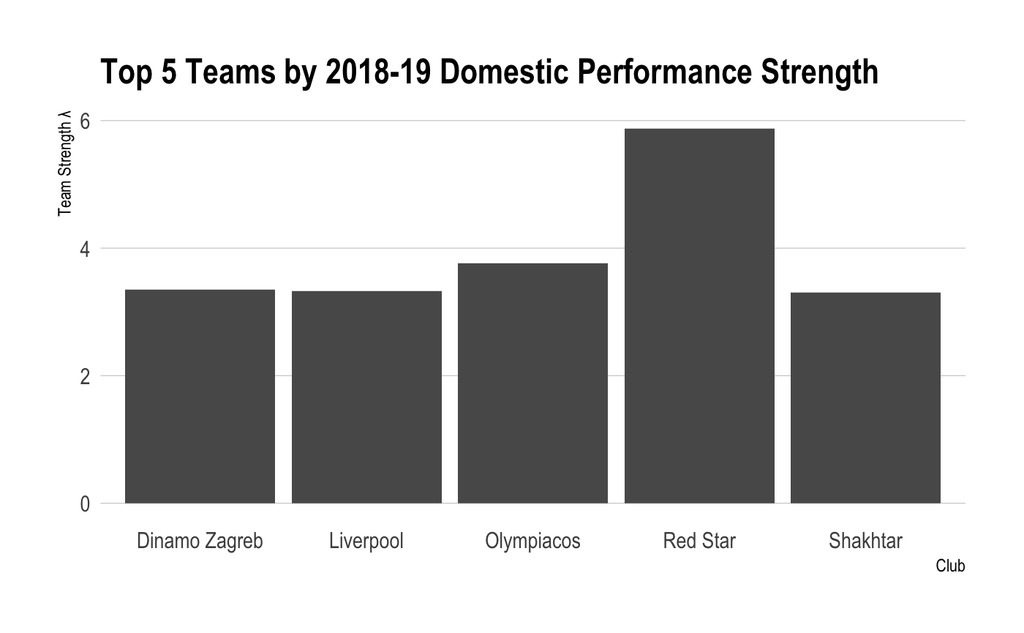

```
uefa = remove_xg(uefa)
```

```
uefa = read_csv('../data/raw/UEFA_Champions_League_2020_Results_RAW.csv')

uefa_playoff_teams = c(
  "Atalanta", "RB Leipzig", "Barcelona", "Manchester City",
  "Lyon", "Paris S-G", "Atlético Madrid", "Bayern Munich"
)

uefa_playoff_teams
```

```
[1] "Atalanta"        "RB Leipzig"      "Barcelona"       "Manchester City" "Lyon"            "Paris S-G"       "Atlético Madrid" "Bayern Munich"
```

```
uefa_group_ro16 = uefa %>% filter(Round %in% c("Group stage", "Round of 16"))

uefa_group_ro16
```

| Competition_Name | Gender | Country | Season_End_Year | Round | Wk | Day | Date | Time | Home | HomeGoals | Home_xG | Away | AwayGoals | Away_xG | Attendance | Venue | Referee | Notes | MatchURL |
| --- | --- | --- | --- | --- | --- | --- | --- | --- | --- | --- | --- | --- | --- | --- | --- | --- | --- | --- | --- |
| UEFA Champions League | M | NA | 2020 | Group stage | 1 | Tue | 2019-09-17 | 18:55:00 | Lyon fr | 1 | 1.6 | ru Zenit | 1 | 1.0 | 47201 | Groupama Stadium | Michael Oliver | NA | https://fbref.com/en/matches/7f6a5ede/Lyon-Zenit-September-17-2019-Champions-League |
| UEFA Champions League | M | NA | 2020 | Group stage | 1 | Tue | 2019-09-17 | 18:55:00 | Inter it | 1 | 1.4 | cz Slavia Prague | 1 | 1.0 | 50128 | Stadio Giuseppe Meazza | Ruddy Buquet | NA | https://fbref.com/en/matches/b56e2c3b/Internazionale-Slavia-Prague-September-17-2019-Champions-League |
| UEFA Champions League | M | NA | 2020 | Group stage | 1 | Tue | 2019-09-17 | 20:00:00 | Benfica pt | 1 | 1.8 | de RB Leipzig | 2 | 1.0 | 46460 | Estádio do Sport Lisboa e Benfica | Tasos Sidiropoulos | NA | https://fbref.com/en/matches/f871df3b/Benfica-RB-Leipzig-September-17-2019-Champions-League |
| UEFA Champions League | M | NA | 2020 | Group stage | 1 | Tue | 2019-09-17 | 20:00:00 | Chelsea eng | 0 | 2.8 | es Valencia | 1 | 1.0 | 39469 | Stamford Bridge | Cüneyt Çakιr | NA | https://fbref.com/en/matches/8c3140a0/Chelsea-Valencia-September-17-2019-Champions-League |
| UEFA Champions League | M | NA | 2020 | Group stage | 1 | Tue | 2019-09-17 | 21:00:00 | RB Salzburg at | 6 | 4.3 | be Genk | 2 | 0.7 | 29520 | Red Bull Arena | Felix Zwayer | NA | https://fbref.com/en/matches/5b62cee4/Red-Bull-Salzburg-Genk-September-17-2019-Champions-League |
| UEFA Champions League | M | NA | 2020 | Group stage | 1 | Tue | 2019-09-17 | 21:00:00 | Ajax nl | 3 | 1.5 | fr Lille | 0 | 2.0 | 51441 | Johan Cruyff ArenA | Srđan Jovanović | NA | https://fbref.com/en/matches/602b7cb7/Ajax-Lille-September-17-2019-Champions-League |
| UEFA Champions League | M | NA | 2020 | Group stage | 1 | Tue | 2019-09-17 | 21:00:00 | Napoli it | 2 | 1.8 | eng Liverpool | 0 | 0.7 | 38878 | Stadio San Paolo | Felix Brych | NA | https://fbref.com/en/matches/83579d2e/Napoli-Liverpool-September-17-2019-Champions-League |
| UEFA Champions League | M | NA | 2020 | Group stage | 1 | Tue | 2019-09-17 | 21:00:00 | Dortmund de | 0 | 3.4 | es Barcelona | 0 | 0.4 | 66099 | Signal Iduna Park | Ovidiu Hațegan | NA | https://fbref.com/en/matches/15996455/Dortmund-Barcelona-September-17-2019-Champions-League |
| UEFA Champions League | M | NA | 2020 | Group stage | 1 | Wed | 2019-09-18 | 18:55:00 | Club Brugge be | 0 | 1.7 | tr Galatasaray | 0 | 0.6 | 26616 | Jan Breydelstadion | Slavko Vinčič | NA | https://fbref.com/en/matches/7b5b1e42/Club-Brugge-Galatasaray-September-18-2019-Champions-League |
| UEFA Champions League | M | NA | 2020 | Group stage | 1 | Wed | 2019-09-18 | 19:55:00 | Olympiacos gr | 2 | 1.7 | eng Tottenham | 2 | 1.7 | 31001 | Stadio Georgios Karaiskáki | Gianluca Rocchi | NA | https://fbref.com/en/matches/a6045d6f/Olympiacos-Tottenham-Hotspur-September-18-2019-Champions-League |

[output cut: 102 more lines]

```
all_combined = all %>% rbind(uefa)


head(all_combined)
```

| Competition_Name | Gender | Country | Season_End_Year | Round | Wk | Day | Date | Time | Home | HomeGoals | Away | AwayGoals | Attendance | Venue | Referee | Notes | MatchURL |
| --- | --- | --- | --- | --- | --- | --- | --- | --- | --- | --- | --- | --- | --- | --- | --- | --- | --- |
| Austrian Football Bundesliga | M | AUT | 2019 | Regular season | 1 | Fri | 2018-07-27 | 20:45:00 | Austria Wien | 2 | Wacker Innsbr | 1 | 12673 | Generali Arena | Christopher Jäger | NA | https://fbref.com/en/matches/6c36d5e8/Austria-Wien-Wacker-Innsbruck-July-27-2018-Austrian-Bundesliga |
| Austrian Football Bundesliga | M | AUT | 2019 | Regular season | 1 | Sat | 2018-07-28 | 17:00:00 | SCR Altach | 2 | Mattersburg | 3 | 4523 | CASHPOINT Arena | Dieter Muckenhammer | NA | https://fbref.com/en/matches/b5940ee5/Rheindorf-Altach-Mattersburg-July-28-2018-Austrian-Bundesliga |
| Austrian Football Bundesliga | M | AUT | 2019 | Regular season | 1 | Sat | 2018-07-28 | 17:00:00 | Sturm Graz | 3 | Hartberg | 2 | 10785 | Merkur Arena | Rene Eisner | NA | https://fbref.com/en/matches/f54b7835/Sturm-Graz-Hartberg-July-28-2018-Austrian-Bundesliga |
| Austrian Football Bundesliga | M | AUT | 2019 | Regular season | 1 | Sun | 2018-07-29 | 17:00:00 | St. Pölten | 4 | Wolfsberger AC | 3 | 2786 | NV Arena | Robert Schörgenhofer | NA | https://fbref.com/en/matches/44323758/St-Polten-Wolfsberger-AC-July-29-2018-Austrian-Bundesliga |
| Austrian Football Bundesliga | M | AUT | 2019 | Regular season | 1 | Sun | 2018-07-29 | 17:00:00 | Admira | 0 | Rapid Wien | 3 | 5200 | BSFZ-Arena | Alexander Harkam | NA | https://fbref.com/en/matches/9b206c50/Admira-Wacker-Modling-Rapid-Wien-July-29-2018-Austrian-Bundesliga |
| Austrian Football Bundesliga | M | AUT | 2019 | Regular season | 1 | Sun | 2018-07-29 | 17:00:00 | RB Salzburg | 3 | LASK | 1 | 11532 | Red Bull Arena | Harald Lechner | NA | https://fbref.com/en/matches/7704f43d/Red-Bull-Salzburg-LASK-July-29-2018-Austrian-Bundesliga |

```
no_ties_combined = all_combined %>%
  filter(HomeGoals != AwayGoals) %>%
  mutate(Home_Winner = as.numeric(HomeGoals > AwayGoals),
         Opp_Winner  = as.numeric(AwayGoals > HomeGoals))

unik_teams = sort(unique(c(no_ties_combined$Home, no_ties_combined$Away)))

results_combined = no_ties_combined %>%
  rename(home.team = Home, away.team = Away) %>%
  group_by(home.team, away.team) %>%
  summarise(
    home.win = sum(Home_Winner),
    away.win = sum(Opp_Winner),
    .groups = "drop"
  ) %>%
  mutate(
    home.team = factor(home.team, levels = unik_teams),
    away.team = factor(away.team, levels = unik_teams)
  )


fit_all = BTm(
  outcome = cbind(home.win, away.win),
  player1 = home.team,
  player2 = away.team,
  refcat = "Yenisey",
  data = results_combined
)
```

```
combined_lambda_hat = as.data.frame(BradleyTerry2::BTabilities(fit_all)) %>%
  rownames_to_column("team") %>%
  arrange(desc(ability))

combined_lambda_hat
```

| team | ability | s.e. |
| --- | --- | --- |
| Slavia Prague | 2.067900e+01 | 3.956180e+03 |
| Viktoria Plzeň | 2.049829e+01 | 3.956180e+03 |
| Sparta Prague | 1.952134e+01 | 3.956180e+03 |
| Jablonec | 1.914797e+01 | 3.956180e+03 |
| PAOK | 1.886543e+01 | 6.693690e+02 |
| Mladá Boleslav | 1.886308e+01 | 3.956180e+03 |
| Baník Ostrava | 1.863311e+01 | 3.956180e+03 |
| Slovan Liberec | 1.850539e+01 | 3.956180e+03 |
| Sigma Olomouc | 1.844173e+01 | 3.956180e+03 |
| Fastav Zlín | 1.841409e+01 | 3.956180e+03 |

[output cut: 337 more lines]

```
NA
```

```
plot = ggplot2::ggplot(combined_lambda_hat %>% arrange(desc(ability)) %>% head(5), aes(reorder(team, -ability), ability)) +
  ggplot2::geom_col() +
  labs(title = "Top 5 Teams by UCL 2019-2020 Group Stage + RO16 Performance Strength", x = "Club", y = "Team Strength λ")
plot
```

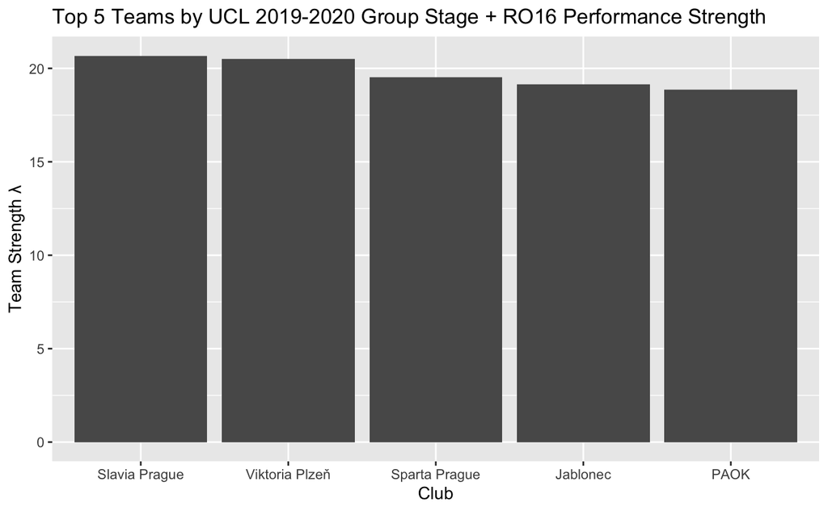

```
uefa_playoff_teams= c(
  "Atalanta", "RB Leipzig", "Barcelona", "Manchester City",
  "Lyon", "Paris S-G", "Atlético Madrid", "Bayern Munich"
)

combined_lambda_hat = combined_lambda_hat %>%
  filter(team %in% uefa_playoff_teams)

combined_lambda_hat %>% arrange(desc(ability))
```

| team | ability | s.e. |
| --- | --- | --- |
| Paris S-G | 2.5871996 | 0.6797405 |
| Barcelona | 2.5401725 | 0.7525521 |
| Manchester City | 2.0782767 | 0.7119963 |
| Lyon | 1.7296549 | 0.6404800 |
| Atlético Madrid | 1.6782414 | 0.6414430 |
| Bayern Munich | 1.6620514 | 0.7153158 |
| Atalanta | 1.0936900 | 0.5903573 |
| RB Leipzig | 0.9345248 | 0.6670111 |

```
strength_plot = combined_lambda_hat %>%
  arrange(desc(ability)) %>%
  ggplot(aes(x = reorder(team, ability), y = ability)) +
  geom_col(fill = "#1f78b4", width = 0.7) +
  geom_text(aes(label = round(ability, 2)),
            hjust = -0.1, size = 4, color = "black") +
  coord_flip(clip = "off") +
  scale_y_continuous(
    expand = expansion(mult = c(0, 0.1))
  ) +
  labs(
    title = "Playoff Teams Strengths",
    subtitle = "Bradley–Terry Model Estimated Team Abilities (λ)",
    x = "Team",
    y = "Ability (λ)"
  ) +
  theme_minimal(base_size = 13) +
  theme(
    plot.title = element_text(face = "bold"),
    plot.subtitle = element_text(size = 11, color = "gray30"),
    axis.text.y = element_text(face = "bold"),
    axis.title.y = element_text(vjust = 1),
    panel.grid.major.y = element_blank(),
    panel.grid.minor = element_blank(),
    plot.margin = margin(10, 40, 10, 10)
  )

ggsave("playoffteam_strengths.png", width = 8, height = 5, dpi = 300)
strength_plot
```

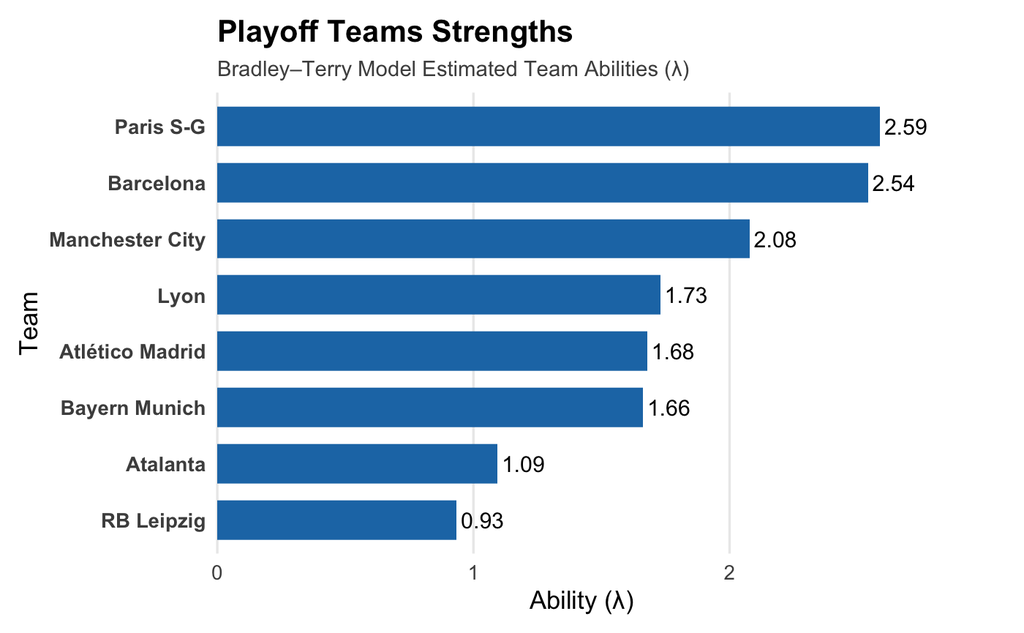

```
avg_goals = uefa %>%
  filter(Round %in% c("Group stage", "Round of 16")) %>%
  mutate(total_goals = HomeGoals + AwayGoals) %>%
  summarise(avg_goals = mean(total_goals, na.rm = TRUE))

avg_goals
```

| avg_goals |
| --- |
| 3.205357 |

```
quarters = data.frame(
  Hi = c("Atalanta", "RB Leipzig", "Barcelona", "Manchester City"),
  Lo = c("Paris S-G", "Atlético Madrid", "Bayern Munich", "Lyon"),
  stringsAsFactors = FALSE
)

quarters
```

| Hi | Lo |
| --- | --- |
| Atalanta | Paris S-G |
| RB Leipzig | Atlético Madrid |
| Barcelona | Bayern Munich |
| Manchester City | Lyon |

```
NA
```

##### Two-legged quarter-finals and semi-finals simulation

In the 19/20 UCL season, the quarter-finals and semi-finals were changed from being 2 legged to just a one leg match. We will simulate the quarter-finals and semi-finals as if it were 2-legged by using the aggregate goals to decide the winner over the two legs. To simulate how many goals a team would score, we use the team’s ability based on the Bradley-Terry model and the average goal scored over the UCL Group Stage and Round of 16

```
# compute win probabilities
possible_matchups = quarters %>%
  dplyr::left_join(combined_lambda_hat %>% dplyr::select(team, ability),
                   by = c("Hi" = "team")) %>%
  dplyr::rename(Hi_ability = ability) %>%
  dplyr::left_join(combined_lambda_hat %>% dplyr::select(team, ability),
                   by = c("Lo" = "team")) %>%
  dplyr::rename(Lo_ability = ability) %>%
  dplyr::mutate(
    # expected goal rate scaling based on relative Bradley-Terry abilities
    Hi_lambda = exp(Hi_ability) / (exp(Hi_ability) + exp(Lo_ability)) * 3.205357,
    Lo_lambda = exp(Lo_ability) / (exp(Hi_ability) + exp(Lo_ability)) * 3.205357
  )

# Helper function for 2-leg tie using aggregate goals
simulate_two_leg_goals = function(ability_hi, ability_lo, avg_goals = 3.205357) {
  # Convert BT abilities into expected goal rates per match
  lambda_hi = exp(ability_hi) / (exp(ability_hi) + exp(ability_lo)) * avg_goals
  lambda_lo = exp(ability_lo) / (exp(ability_hi) + exp(ability_lo)) * avg_goals

  # Simulate goals for each of the two legs
  # Each team plays two matches, goals ~ Poisson distributed
  leg1_hi = rpois(1, lambda_hi)
  leg1_lo = rpois(1, lambda_lo)
  leg2_hi = rpois(1, lambda_hi)
  leg2_lo = rpois(1, lambda_lo)

  # Aggregate total goals across both legs
  total_hi = leg1_hi + leg2_hi
  total_lo = leg1_lo + leg2_lo

  # Decide winner based on aggregate goals
  if (total_hi > total_lo) {
    return(1)  # Hi team advances
  } else if (total_lo > total_hi) {
    return(0)  # Lo team advances
  } else {
    # Tie after two legs
    # Compute win probability based on relative abilities
    prob_hi_wins_tiebreak = exp(ability_hi) / (exp(ability_hi) + exp(ability_lo))
    return(rbinom(1, 1, prob_hi_wins_tiebreak))  # weighted shootout
  }
}

possible_matchups
```

| Hi | Lo | Hi_ability | Lo_ability | Hi_lambda | Lo_lambda |
| --- | --- | --- | --- | --- | --- |
| Atalanta | Paris S-G | 1.0936900 | 2.587200 | 0.5878482 | 2.6175088 |
| RB Leipzig | Atlético Madrid | 0.9345248 | 1.678241 | 1.0327403 | 2.1726167 |
| Barcelona | Bayern Munich | 2.5401725 | 1.662051 | 2.2643691 | 0.9409879 |
| Manchester City | Lyon | 2.0782767 | 1.729655 | 1.8792474 | 1.3261096 |

```
n_sims = 10000

alt_results = data.frame(
  QF_Match1 = rep(NA, n_sims),
  QF_Match2 = rep(NA, n_sims),
  QF_Match3 = rep(NA, n_sims),
  QF_Match4 = rep(NA, n_sims),
  QF_Winner1 = rep(NA, n_sims),
  QF_Winner2 = rep(NA, n_sims),
  QF_Winner3 = rep(NA, n_sims),
  QF_Winner4 = rep(NA, n_sims),
  SF_Match1 = rep(NA, n_sims),
  SF_Match2 = rep(NA, n_sims),
  SF1_Winner = rep(NA, n_sims),
  SF2_Winner = rep(NA, n_sims),
  Finals_Hi = rep(NA, n_sims),
  Finals_Lo = rep(NA, n_sims),
  Champion = rep(NA, n_sims)
)

for (r in 1:n_sims) {
  set.seed(321 + r)

  # qf
  qf_winners = rep(NA, nrow(possible_matchups))

  for (i in 1:nrow(possible_matchups)) {
    result = simulate_two_leg_goals(
      ability_hi = possible_matchups$Hi_ability[i],
      ability_lo = possible_matchups$Lo_ability[i],
      avg_goals = 3.205357
    )
    qf_winners[i] = ifelse(result == 1, possible_matchups$Hi[i], possible_matchups$Lo[i])

    # store QF matchups
    alt_results[r, paste0("QF_Match", i)] =
      paste(possible_matchups$Hi[i], "vs", possible_matchups$Lo[i])
    alt_results[r, paste0("QF_Winner", i)] = qf_winners[i]
  }

```

[output cut: 50 more lines]

```
  alt_results[r, "Finals_Hi"] = finals$Hi[1]
  alt_results[r, "Finals_Lo"] = finals$Lo[1]

  # simulate one-leg final
  final_outcome = rbinom(1, 1, finals$prob[1])
  alt_results[r, "Champion"] =
    ifelse(final_outcome == 1, finals$Hi[1], finals$Lo[1])
}

# results
champions = alt_results %>%
  dplyr::count(Champion, sort = TRUE) %>%
  dplyr::mutate(Prob = n / n_sims)

champions
```

| Champion | n | Prob |
| --- | --- | --- |
| Paris S-G | 4862 | 0.4862 |
| Barcelona | 3468 | 0.3468 |
| Manchester City | 827 | 0.0827 |
| Atlético Madrid | 451 | 0.0451 |
| Lyon | 206 | 0.0206 |
| Bayern Munich | 147 | 0.0147 |
| Atalanta | 24 | 0.0024 |
| RB Leipzig | 15 | 0.0015 |

```
NA
```

```
champions_plot = champions %>%
  ggplot(aes(x = reorder(Champion, Prob), y = Prob)) +
  geom_col(fill = "#1f78b4") +
  geom_text(aes(label = scales::percent(Prob, accuracy = 0.1)),
            hjust = -0.1, size = 4) +
  coord_flip(clip = "off") +
  scale_y_continuous(labels = scales::percent_format(accuracy = 1), limits = c(0, max(champions$Prob) * 1.15)) +
  labs(
    title = "Simulated Champions (10,000 Runs)",
    subtitle = "2019–20 UEFA Champions League (BT + Poisson Model)",
    x = "Team",
    y = "Probability of Winning"
  ) +
  theme_minimal(base_size = 13) +
  theme(
    plot.title = element_text(face = "bold"),
    axis.title.y = element_text(vjust = 1),
    axis.text.y = element_text(face = "bold"),
    plot.margin = margin(10, 40, 10, 10)
  )

ggsave("champions_plot.png", champions_plot, width = 8, height = 5, dpi = 300)

champions_plot
```

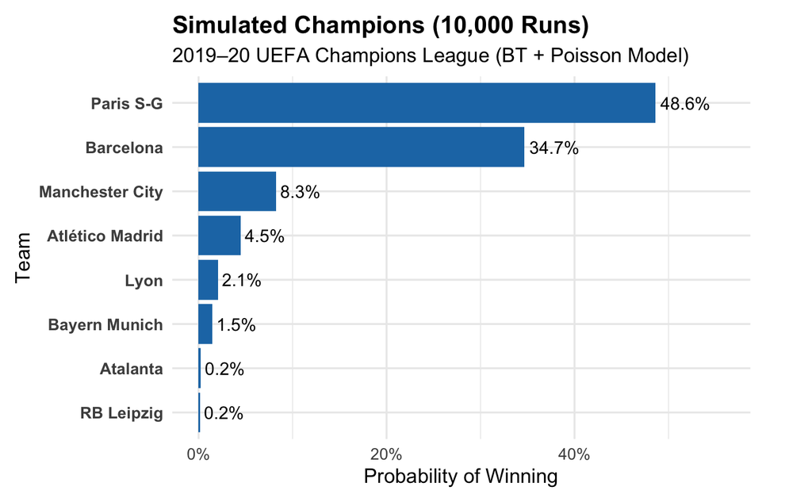

```
sf_matchups = alt_results %>%
  select(SF_Match1, SF_Match2) %>%
  pivot_longer(cols = everything(), values_to = "Matchup") %>%
  count(Matchup, sort = TRUE) %>%
  mutate(Prob = n / n_sims)

sf_plot = sf_matchups %>%
  ggplot(aes(x = reorder(Matchup, Prob), y = Prob)) +
  geom_col(fill = "#1f78b4") +
  geom_text(
    aes(label = scales::percent(Prob, accuracy = 0.1)),
    hjust = -0.1, size = 4
  ) +
  coord_flip(clip = "off") +
  scale_y_continuous(
    labels = scales::percent_format(accuracy = 1),
    limits = c(0, max(sf_matchups$Prob) * 1.15)
  ) +
  labs(
    title = "Most Common Semifinal Matchups (10,000 Runs)",
    subtitle = "2019–20 UEFA Champions League Simulation (Bradley–Terry + Poisson)",
    x = "Semifinal Matchup",
    y = "Probability"
  ) +
  theme_minimal(base_size = 13) +
  theme(
    plot.title = element_text(face = "bold"),
    axis.title.y = element_text(vjust = 1),
    axis.text.y = element_text(face = "bold"),
    plot.margin = margin(10, 40, 10, 10)
  )

ggsave("ucl_semifinal_matchups.png", sf_plot, width = 8, height = 5, dpi = 300)
sf_plot



final_matchups = alt_results %>%
  mutate(
    Final_Pair = paste(
```

[output cut: 20 more lines]

```
  labs(
    title = "Most Common Final Matchups (10,000 Runs)",
    subtitle = "2019–20 UEFA Champions League Simulation (Bradley–Terry + Poisson)",
    x = "Final Matchup",
    y = "Probability"
  ) +
  theme_minimal(base_size = 13) +
  theme(
    plot.title = element_text(face = "bold"),
    axis.title.y = element_text(vjust = 1),
    axis.text.y = element_text(face = "bold"),
    plot.margin = margin(10, 40, 10, 10)
  )

ggsave("ucl_final_matchups.png", final_plot, width = 8, height = 5, dpi = 300)
```

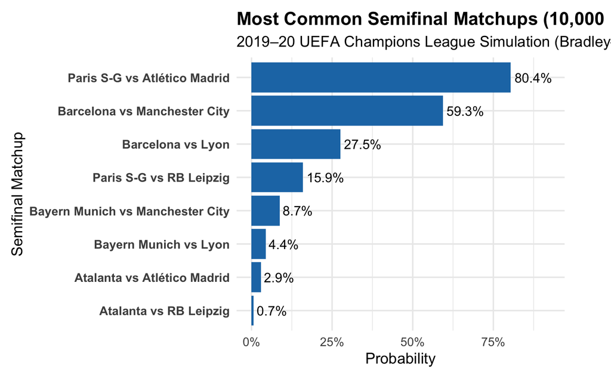

```
final_plot
```

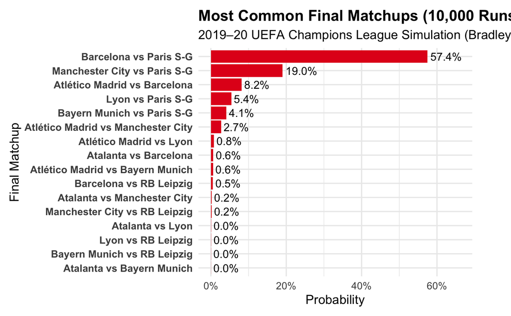

## References

Deshpande, Sameer. 2025. “Lecture 12: Bradley-Terry Models.” University of Wisconsin-Madison. https://skdeshpande91.github.io/stat479_fall2025/lectures/lecture12.html.

[^1]: Members from the following domestic leagues took part in the 2019-20 UEFA Champions League group stage: *Austrian Football Bundesliga, Belgian Pro League, Croatian Football League, Czech First League, English Premier League, French Ligue 1, German Fusball Bundesliga, Greek Super League, Italian Serie A, Dutch Eredivise, Portugese Premeira Liga, Russian Premier League, Serbian SuperLiga, Spanish La Liga, Turkish Super Lig, Ukrainian Premier League*
[^2]: Specific links and FBRef pages used can be found in the *GettingRawMatchupData.Rmd* notebook.
[^3]: https://en.wikipedia.org/wiki/UEFA_coefficient